# Classification binaire

Il s’agit d’un extrait de la formation. Cette formation peut se faire en présentiel ou à distance. Pour en savoir plus, merci de me contacter.

# 1 Introduction

- Illustration de la classification binaire avec un ensemble d’algorithmes classiques
- Importance de l’interprétabilité des modèles
- Importance de la mesure de performance des modèles (AUC, taux de précision, spécificité et autres)
- Mise en place d’un procession opérationnel avec les résultats

# 2 Préparation des bases

# 3 Arbres de classification

## 3.1 Apprentissage de l’arbre de décision

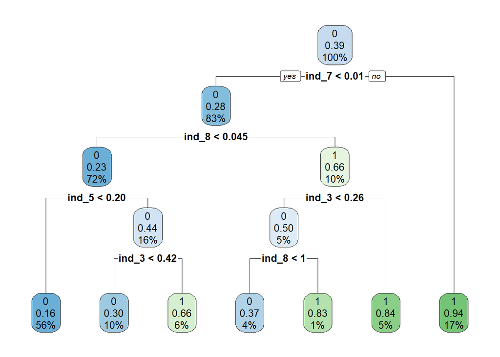

## 3.2 Matrice de confusion

```
## Confusion Matrix and Statistics
##
##           Reference
## Prediction   0   1
##          0 779 180
##          1  57 363
##
##                Accuracy : 0.8281
##                  95% CI : (0.8072, 0.8477)
##     No Information Rate : 0.6062
##     P-Value [Acc > NIR] : < 2.2e-16
##
##                   Kappa : 0.6251
##  Mcnemar's Test P-Value : 2.286e-15
##
##             Sensitivity : 0.9318
##             Specificity : 0.6685
##          Pos Pred Value : 0.8123
##          Neg Pred Value : 0.8643
##              Prevalence : 0.6062
##          Detection Rate : 0.5649
##    Detection Prevalence : 0.6954
##       Balanced Accuracy : 0.8002
##
##        'Positive' Class : 0
##
```

## 3.3 Courbe ROC

Prédiction des résultats en terme de probabilité

```
##            0         1
## 1 0.33838384 0.6616162
## 2 0.06049822 0.9395018
## 3 0.06049822 0.9395018
## 4 0.06049822 0.9395018
## 5 0.06049822 0.9395018
## 6 0.17021277 0.8297872
```

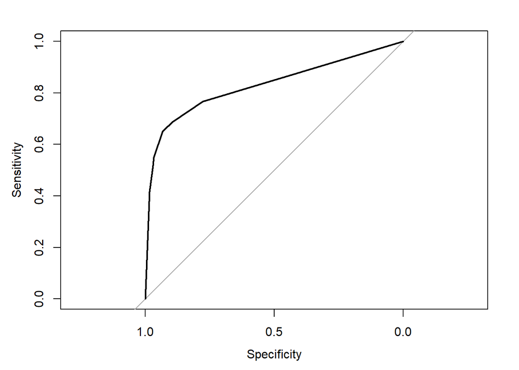

## 3.4 Visualisation

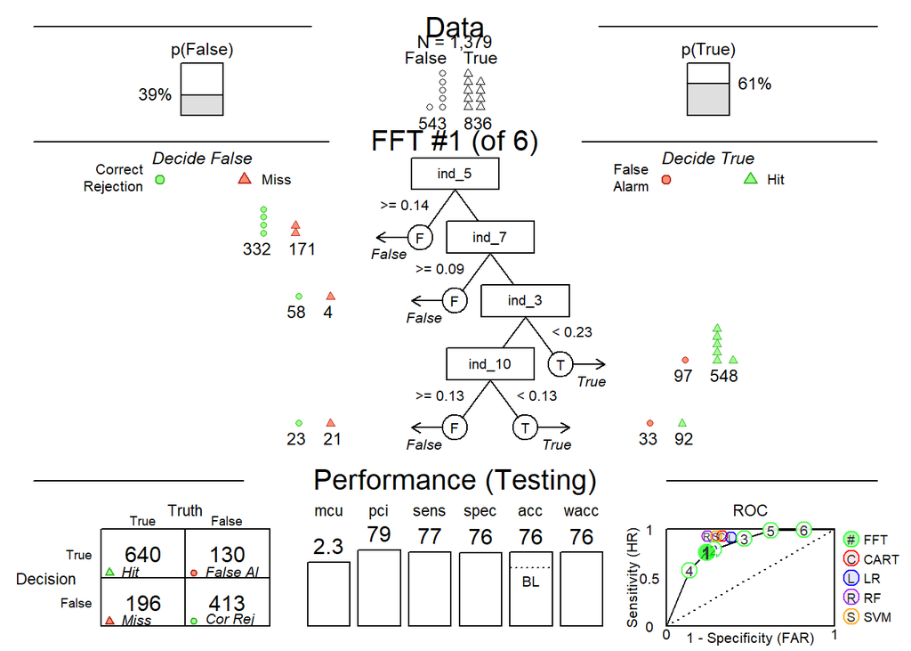

**Visualisation interactive**

[interactive chart not shown]

# 4 Analyse Discriminante

## 4.1 Apprentissage

## 4.2 Visualisation

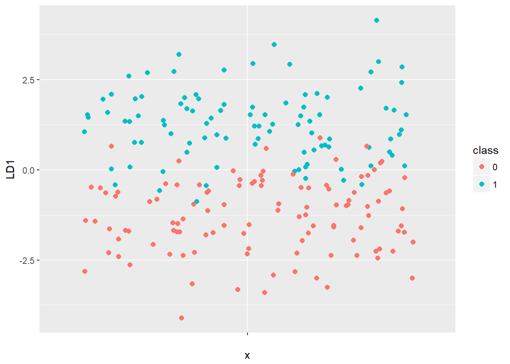

# 5 SVM

## 5.1 Apprentissage

## 5.2 Matrice de confusion

```
## Confusion Matrix and Statistics
##
##           Reference
## Prediction   0   1
##          0 775 148
##          1  61 395
##
##                Accuracy : 0.8484
##                  95% CI : (0.8284, 0.867)
##     No Information Rate : 0.6062
##     P-Value [Acc > NIR] : < 2.2e-16
##
##                   Kappa : 0.6734
##  Mcnemar's Test P-Value : 2.702e-09
##
##             Sensitivity : 0.9270
##             Specificity : 0.7274
##          Pos Pred Value : 0.8397
##          Neg Pred Value : 0.8662
##              Prevalence : 0.6062
##          Detection Rate : 0.5620
##    Detection Prevalence : 0.6693
##       Balanced Accuracy : 0.8272
##
##        'Positive' Class : 0
##
```

# 6 Regression Logistique

## 6.1 Apprentissage

```
##
## Call:
## glm(formula = class ~ ., family = binomial(link = "logit"), data = a)
##
## Deviance Residuals:
##     Min       1Q   Median       3Q      Max
## -4.8887  -0.6883  -0.5739   0.6667   1.9673
##
## Coefficients:
##             Estimate Std. Error z value Pr(>|z|)
## (Intercept) -1.72035    0.06665 -25.810  < 2e-16 ***
## ind_1        0.78617    0.14046   5.597 2.18e-08 ***
## ind_2       -0.04664    0.04581  -1.018 0.308561
## ind_3        0.58540    0.08456   6.923 4.43e-12 ***
## ind_4        1.90852    1.00260   1.904 0.056965 .
## ind_5        0.70931    0.07864   9.020  < 2e-16 ***
## ind_6        1.11693    0.16949   6.590 4.40e-11 ***
## ind_7        4.34180    0.36559  11.876  < 2e-16 ***
## ind_8        1.81592    0.20319   8.937  < 2e-16 ***
## ind_9        1.83464    0.20075   9.139  < 2e-16 ***
## ind_10       0.23172    0.06863   3.377 0.000734 ***
## ---
## Signif. codes:  0 '***' 0.001 '**' 0.01 '*' 0.05 '.' 0.1 ' ' 1
##
## (Dispersion parameter for binomial family taken to be 1)
##
##     Null deviance: 4321.2  on 3221  degrees of freedom
## Residual deviance: 3093.2  on 3211  degrees of freedom
## AIC: 3115.2
##
## Number of Fisher Scoring iterations: 9
```

## 6.2 Prédictions

La régression logistique n’est pas un algorithme de classification à proprement parler. Il s’agit de la régression de la probabilité. Pour utiliser le résultat de régression, on doit choisir un seuil pour avoir les prédictions.

```
## Confusion Matrix and Statistics
##
##           Reference
## Prediction   0   1
##          0 771 208
##          1  65 335
##
##                Accuracy : 0.802
##                  95% CI : (0.78, 0.8228)
##     No Information Rate : 0.6062
##     P-Value [Acc > NIR] : < 2.2e-16
##
##                   Kappa : 0.5653
##  Mcnemar's Test P-Value : < 2.2e-16
##
##             Sensitivity : 0.9222
##             Specificity : 0.6169
##          Pos Pred Value : 0.7875
##          Neg Pred Value : 0.8375
##              Prevalence : 0.6062
##          Detection Rate : 0.5591
##    Detection Prevalence : 0.7099
##       Balanced Accuracy : 0.7696
##
##        'Positive' Class : 0
##
```

# 7 kNN

## 7.2 Création de partition

Pour tester l’algorithme, on répartit les données en deux bases : base d’apprentissage et base de test.

## 7.3 Prédiction

On peut faire la prédiction des classes de la base de test à l’aide la fonction `knn` du package `class`. On peut choisir dans un premier temps `k=5`.

# 8 Classification Naïve bayésienne

# 9 Synthèse des modèles

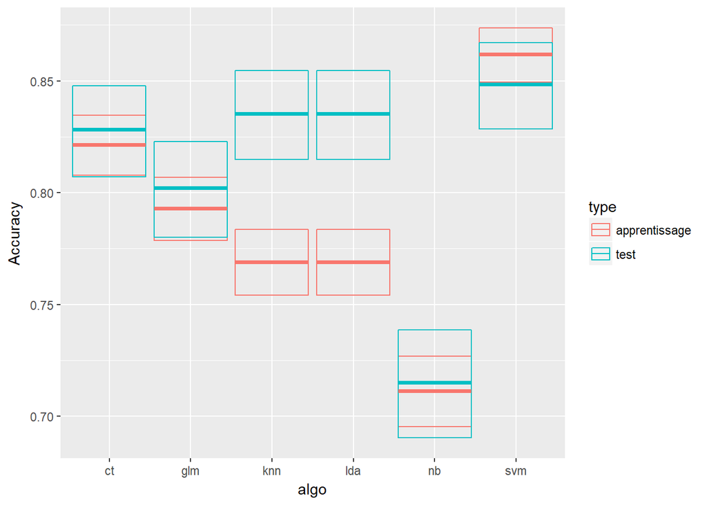

# 10 Agrégation de modèles

## 10.1 Bagging

## 10.2 Foret Aleatoire

# 11 Synthèse Finale

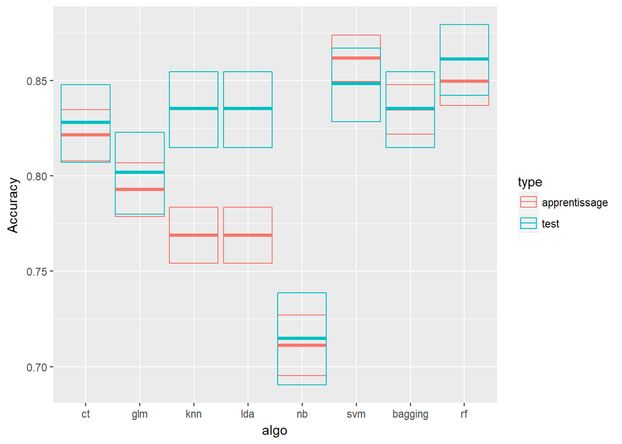